# Module 10 HW

Zachary Gonzalez

2022-03-30

Question 1

```r
library(multtest)
data(golub)
```

part a - single vs ward

```r
gol.fac <- factor(golub.cl, levels=0:1, labels = c("ALL", "AML"))
clusterdata <- data.frame(golub[1042,])
#clusterdata <- as.numeric(unlist(clusterdata))
hc.single <- hclust(dist(clusterdata,method="euclidian"),method="single")
hc.ward <- hclust(dist(clusterdata,method="euclidian"),method="ward.D2")
```

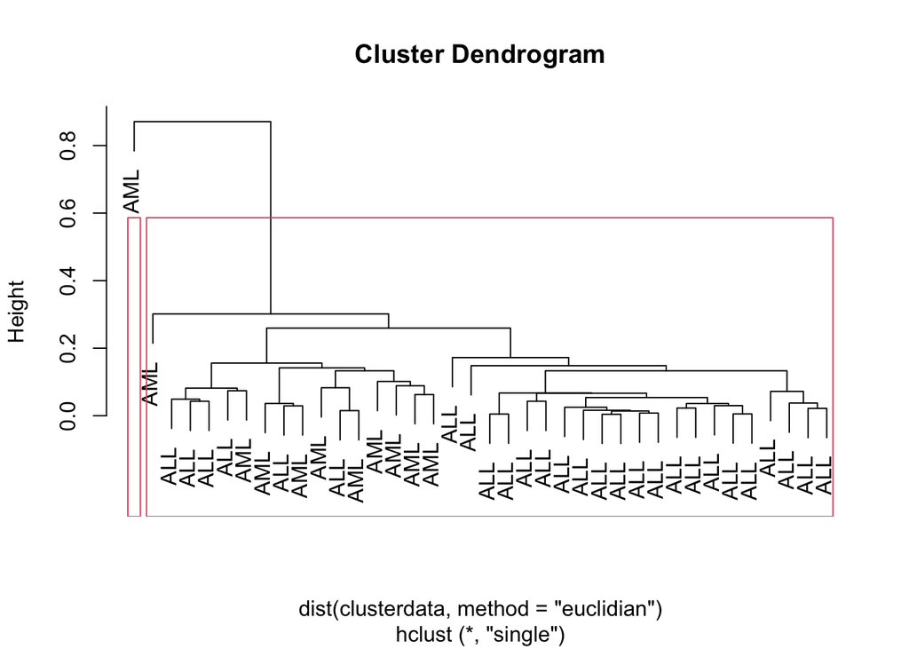

```r
plot(hc.single, labels=gol.fac)
rect.hclust(hc.single,k=2)
```

```r
groups <- cutree(hc.single,k=2)
table(groups, gol.fac)
```

```
##       gol.fac
## groups ALL AML
##      1  27  10
##      2   0   1
```

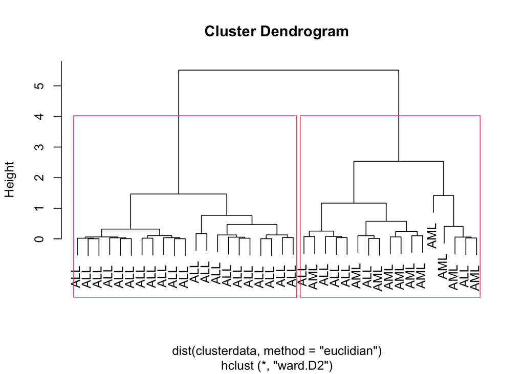

```r
plot(hc.ward, labels=gol.fac)
rect.hclust(hc.ward,k=2)
```

```r
groups <- cutree(hc.ward,k=2)
table(groups, gol.fac)
```

```
##       gol.fac
## groups ALL AML
##      1  21   0
##      2   6  11
```

WHICH METHOD IS BETTER?

The ward linkage function seems to work better in this instance. Unlike the single linkage method, the ward linkage method separates the data into two easy to discern clusters.

part b - k means analysis

```r
k.means <- kmeans(clusterdata, centers=2, nstart = 10)
table(k.means$cluster, gol.fac)
```

```
##    gol.fac
##     ALL AML
##   1  22   1
##   2   5  10
```

part c

part d

```r
k.means
```

```
## K-means clustering with 2 clusters of sizes 23, 15
##
## Cluster means:
##   golub.1042...
## 1      2.045689
## 2      0.738366
##
## Clustering vector:
##  [1] 1 1 1 1 1 1 1 1 1 1 1 1 1 2 1 1 2 2 1 1 2 1 1 1 2 1 1 2 1 2 2 2 2 2 2 2 2 2
##
## Within cluster sum of squares by cluster:
## [1] 2.261185 4.235851
##  (between_SS / total_SS =  70.5 %)
##
## Available components:
##
## [1] "cluster"      "centers"      "totss"        "withinss"     "tot.withinss"
## [6] "betweenss"    "size"         "iter"         "ifault"
```

```r
initial <- k.means$centers
n <- dim(clusterdata)[1]; nboot<-1000
boot.cl <- matrix(NA,nrow=nboot,ncol=2)
for (i in 1:nboot){
  dat.star <- clusterdata[sample(1:n,replace=TRUE),]
  cl <- kmeans(dat.star, initial, nstart = 10)
  boot.cl[i,] <- c(cl$centers[1], cl$centers[2])
}
apply(boot.cl,2,mean)
```

```
## [1] 2.0340188 0.6954431
```

```r
quantile(boot.cl[,1],c(0.025,0.975))
```

```
##     2.5%    97.5%
## 1.819930 2.207609
```

```r
quantile(boot.cl[,2],c(0.025,0.975))
```

```
##      2.5%     97.5%
## 0.1471704 1.0705514
```

part e - plot of k vs sse

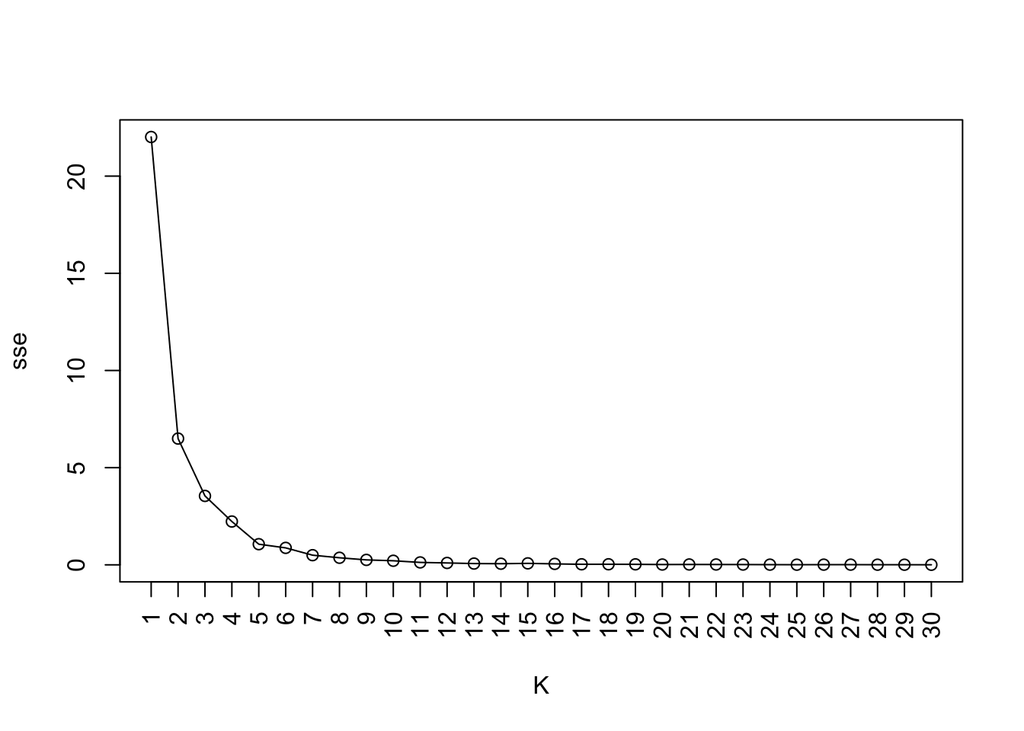

```r
K <- (1:30); sse<-rep(NA,length(K))
for (k in K) {
  sse[k]<-kmeans(clusterdata, centers = k, nstart = 10)$tot.withinss
}
plot(K,sse,type='o',xaxt='n'); axis(1, at = K, las = 2)
```

HOW MANY CLUSTERS THE PLOT SUGGEST

Based on the plot k vs sse plot above, the number of clusters seems to be around 5. This is because the plot drops steeply from K = 1 and seems to level off quickly after K = 5

Question 2

part a

```r
selection1 <- grep("oncogene", golub.gnames[,2])
selection2 <- grep("antigen", golub.gnames[,2])
```

```r
clustdata <- rbind(golub[selection1,], golub[selection2,])
g.name <- rep(c("oncogene", "antigen"), c(length(selection1), length(selection2)))
```

part b

kmeans

```r
k.means_select <- kmeans(clustdata, centers = 2, nstart = 10)
table(k.means_select$cluster, g.name)
```

```
##    g.name
##     antigen oncogene
##   1      34       20
##   2      41       22
```

kmedoids

```r
library(cluster)
k.pam <- pam(clustdata, k=2)
table(k.pam$clustering, g.name)
```

```
##    g.name
##     antigen oncogene
##   1      49       29
##   2      26       13
```

part c - test for marginal independence - do fisher test

```r
fish_test_kmeans <- fisher.test(table(k.means_select$cluster, g.name))
fish_test_kmeans
```

```
##
##  Fisher's Exact Test for Count Data
##
## data:  table(k.means_select$cluster, g.name)
## p-value = 0.8484
## alternative hypothesis: true odds ratio is not equal to 1
## 95 percent confidence interval:
##  0.399907 2.087516
## sample estimates:
## odds ratio
##  0.9129136
```

```r
fish_test_kmedoids <- fisher.test(table(k.pam$clustering, g.name))
fish_test_kmedoids
```

```
##
##  Fisher's Exact Test for Count Data
##
## data:  table(k.pam$clustering, g.name)
## p-value = 0.8383
## alternative hypothesis: true odds ratio is not equal to 1
## 95 percent confidence interval:
##  0.3426507 2.0276730
## sample estimates:
## odds ratio
##   0.846038
```

Due to the relatively large p-values, we fail to reject the null hypothesis of independence for both the k-means and k-medoids clustering methods.

part d - cluster dendograms

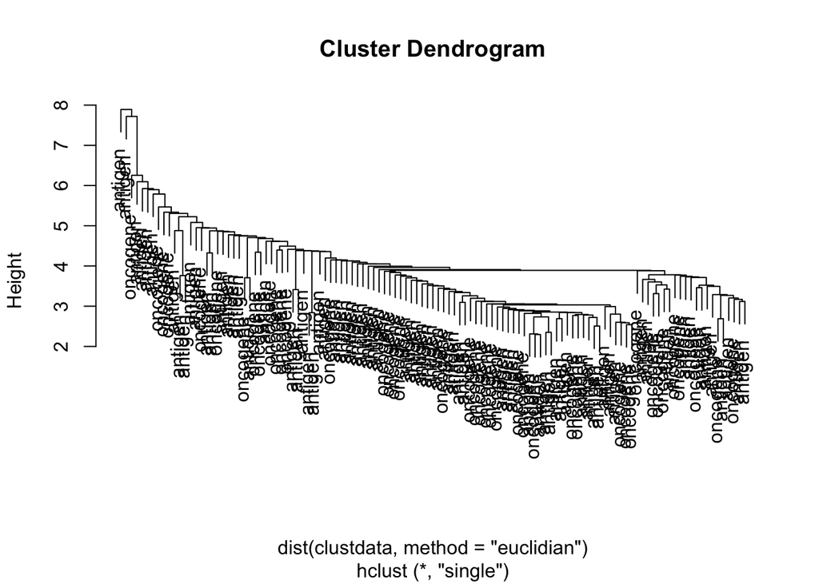

```r
single <- hclust(dist(clustdata,method="euclidian"),method="single")
complete <- hclust(dist(clustdata,method="euclidian"),method="complete")
plot(single, labels=g.name)
```

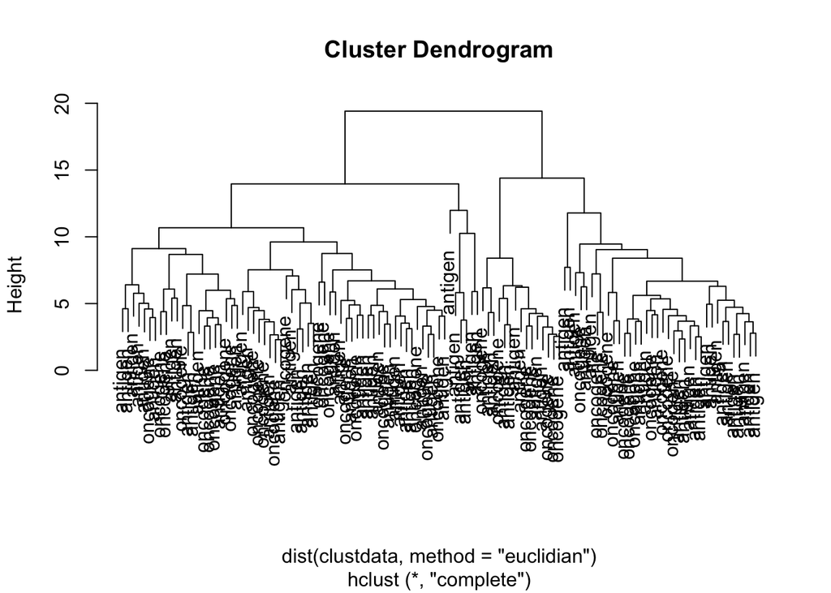

```r
plot(complete, labels=g.name)
```

For this case, complete linkage is a better method than single linkage as it more clearly outlines the separation of clusters.

Question 3

part a

```r
install.packages('ISLR', repos = "http://cran.us.r-project.org")
library(ISLR)
ncidata<-NCI60$data
ncilabs<-NCI60$labs
```

part a - kmeans clustering plot - clusters between 3 and 9

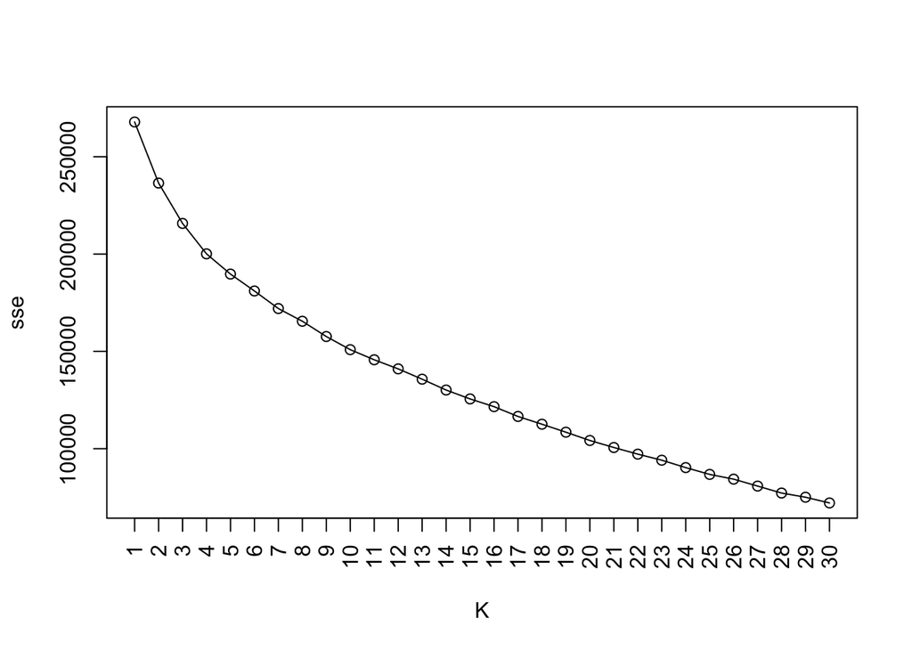

```r
K <- (1:30); sse<-rep(NA,length(K))
for (k in K) {
  sse[k]<-kmeans(ncidata, centers = k, nstart = 10)$tot.withinss
}
plot(K,sse,type='o',xaxt='n'); axis(1, at = K, las = 2)
```

From the above K vs SSE plot, we can see that the graph levels off after around 6-7, retaining a linear descent. This means that the number of clusters is likely around 6-7.

part b - k-medoids clustering

```r
library(cluster)
table(ncilabs,pam(as.dist(1-cor(t(ncidata))), k=7)$cluster)
```

```
##
## ncilabs       1 2 3 4 5 6 7
##   BREAST      0 3 0 0 2 0 2
##   CNS         1 4 0 0 0 0 0
##   COLON       0 0 0 7 0 0 0
##   K562A-repro 0 0 0 0 0 1 0
##   K562B-repro 0 0 0 0 0 1 0
##   LEUKEMIA    0 0 0 0 0 6 0
##   MCF7A-repro 0 0 0 0 1 0 0
##   MCF7D-repro 0 0 0 0 1 0 0
##   MELANOMA    0 1 0 0 0 0 7
##   NSCLC       2 2 0 3 1 1 0
##   OVARIAN     2 0 1 2 1 0 0
##   PROSTATE    0 0 1 1 0 0 0
##   RENAL       7 1 1 0 0 0 0
##   UNKNOWN     0 0 1 0 0 0 0
```